# Deep Learning- 課程 31 - Deep Learning- An introduction to MobileNet Object Detection Images 圖像 目標檢測- Python Tutorial

''' 人工智慧- 進階課程 A.I Tutorials - Advanced Course - Deep Learning 教程 ''' 05 - 深度學習 教程 課程 31 - Deep Learning- An Introduction To MobileNet Part - 01 程式範例 - MobileNet Object Detection Images - 圖像 目標檢測 '''

''' >> 資料準備 >> 你我互動學習園地- 進階課程 Advanced Course >> https://interactiveuandmetutorialsac.weebly.com/ >> 你我互動學習園地 >> https://interactiveuandmetutorials.weebly.com/ >> Python 程式語言 設計 >> https://pythonprogrammingtutorials.weebly.com/ >> 目錄結構 : >> 課程 31 - Deep Learning- An introduction to MobileNet.zip 檔案路徑/ ├── 課程 31 - Deep Learning- An introduction to MobileNet .ipynb ├── MobileNet-Images/ | ├── dog.jpg | ├── eagle.png | ├── person.jpg | ├── | └── zebra.jpg | └── data / '''

[figure not shown]

# MobileNets- Paper 論文參考

- https://arxiv.org/abs/1704.04861
- https://arxiv.org/pdf/1704.04861.pdf
- Google 在 2017年 提出的 MobileNet Model 模型
  - 主要是 因為隨著深度學習的快速發展模型 不但深又巨大
  - 整體參數很可觀 - (比較 流行的模型 幾乎 都以 千萬個參數 為 單位)
  - 而加減乘法運算(Multiplications and Accumulations) 更可以 達到數十億 為單位 的 計算量
  - 這麼 大的模型
  - 不太能在 Mobile/Portable Device 運用
  - 在沒有 大量 GPU幫助下
  - 手機 或 是 即時翻譯 機
  - 無法做到 很好的 Real Time Implementation
- 在大的網路模型中
  - 大部分的計算量都發生在卷積（convolution）計算中
  - 因此
  - 深度可分離卷積神經網絡 Depth-Wise Separable Convolutions Networks
  - 提出來
    - 在不減低太多性能狀態下
    - 盡量減少 原始卷積的計算量

# MobileNets：應用於 移動視覺 高效能 的 卷積神經網絡

- MobileNets: Efficient Convolutional Neural Networks for Mobile Vision Applications

# MobileNets

- 移動 和 嵌入式 視覺應用
- Mobile and Embedded Vision Applications

# MobileNets are based on a Streamlined Architecture

- 基於 精簡架構 體系結構 - Streamlined Architecture
- 模型結構
  - 使用深度方向可分離卷積 Depth-Wise Separable Convolutions
  - 來構建
  - 輕型深度神經網絡 Light Weight Deep Neural Networks

# MobileNetV1 引入了 深度卷積 以減少參數數量

[figure not shown]

# MobileNets Architecture 基於簡化的 體系結構

```
- 深度方向可分離卷積神經網絡  Depth-Wise Separable Convolutions
```

## MobileNets架構 MobileNets Architecture

```
- 有效地在 延遲 和 準確性 之間 - 進行權衡
- Trade Off Between Latency and Accuracy
```

# MobileNet Architecture 架構

```
-  Batch Normalization (BN) and ReLU are applied after each convolution
```

[figure not shown]

- 每次卷積後 都使用 歸一化( Batch Normalization BN 和 (ReLU)
- Batch Normalization (BN) and ReLU are applied after each convolution

[figure not shown]

## 什麼是 深度方向可分離卷積神經網絡 Depth-Wise Separable Convolutions Network ?

- 深度可分離卷積架構 Depth-wise Separable Convolutions Architecture

[figure not shown]

- 卷積運算 - Convolution operation

[figure not shown]

- 輸入資料 : W_in *H_in* Nch (輸入圖的寬*高*輸入channel數)
- Kernel Map : k *k* Nk (Kernel map 寬*高*kernel數，kernel寬高假設一樣)
- 輸出資料 : W_out *H_out* Nk (輸出圖的寬*高*輸出channel數)

[figure not shown]

- 深度可分離卷積 的計算
  - 是希望 在不影響輸出結構的狀態下 減少運算量
  - 基本上可以 拆成兩部分
    1. 深度卷積 Depthwise convolution
    2. 點向卷積 Pointwise convolution
- 1. 深度卷積 Depthwise convolution
     - 針對輸入資料的每一個Channel都建立一個 k * k 的內核
     - 然後每一個 Channel 針對對應的 Kernel都各自（分開）做卷積
     - 和一般卷積不太一樣
       - 一般的捲積計算
         - 是每個內核映射都要和所有 channel 都去做 convolution
         - 這理是 分開獨立去處理

[figure not shown]

- 1. 點向卷積 Pointwise Convolution
     - 輸入資料 - 每個通道做完 Depthwise卷積後 -針對每個點的所有通道

       ```
        - Pointwise 卷積
       ```

     - 回顧複習一下 1×1 的捲積 先
- 1×1 的捲積
  - 1×1捲積 是在 作降維 或是 提高維度用
  - 1×1卷積 也在 處理 channel之間 的合成

[figure not shown]

- 點向卷積 Pointwise Convolution
  - 輸入資料 - 每個通道做完 Depthwise卷積後 -針對每個點的所有通道
  - Pointwise 卷積
- 建立N k個1 *1* N ch的內核映射
  - 將 Depthwise卷積的輸出 做一般1 * 1的 捲積計算

[figure not shown]

- 計算
  - 1.深度卷積 Depthwise convolution : -輸入資料：W *in * H* in *N ch -做每個輸入通道相對應的內核映射（k* k）的捲積
    - 輸出大小為W *out * H* out * N ch
  - 2.點向卷積 Pointwise Convolution： -輸入資料：W *out * H* out *N ch -做一般N k個內核映射（1* 1）的捲積 -輸出大小：W *out * H* out * N k
  - 深度可分離卷積

[figure not shown]

- 計算量 -輸入資料 ：W *in * H* in * N ch
  - 內核圖 ：k *k* N k
  - 輸出資料：W *out * H* out * N k
    - 一般卷積計算量為 W *in * H* in *N ch* k *k* N k
- 深度可分離卷積計算量為
  - Depthwise convolution 計算量 + Pointwise convolution計算量
    - 深度卷積計算量
      - W *in * H* in *N ch* k * k
    - 點向卷積計算量
      - N ch *N k* W *in * H* in
- 當內核映射數量和內核映射數量越多
  - 深度可分離卷積可以節省越多計算量
  - 假設
    - IMput 輸入 - 416 *416* 50
    - Filter - 10個 大小為3 * 3的內核圖
  - 深度可分離卷積 只有一般卷積的
    - 1/10 + 1/9 = 0.211計算量

[figure not shown]

# MoblileNet V2

```
- Mobile Net V2建立在MobileNet V1 [1]的思想的基礎上，使用深度智能可分離卷積作為有效的構建塊。但是，V2向該體系結構引入了兩個新功能：1）層之間的線性瓶頸，以及2）瓶頸之間的短連接
```

[figure not shown]

# MobileNet V3

```
- 通過結合硬件感知的網絡體系結構搜索 (NAS) 和 NetAdapt 演算法
- MobileNet V3 被調整 使用到 手機 中 CPU，隨後通過新的結構優勢進行了, 改進方式
```

[figure not shown]

# MobileNet

- 忽略 警告訊息 Warning Message

```python
import warnings
warnings.filterwarnings("ignore")
```

- 檢查是否 - 有 GPU

```python
from tensorflow.python.client import device_lib
print (device_lib.list_local_devices())
```

```
[name: "/device:CPU:0"
device_type: "CPU"
memory_limit: 268435456
locality {
}
incarnation: 13998530958303753061
, name: "/device:GPU:0"
device_type: "GPU"
memory_limit: 3176441446
locality {
  bus_id: 1
  links {
  }
}
incarnation: 1714263740825375293
physical_device_desc: "device: 0, name: GeForce GTX 980M, pci bus id: 0000:01:00.0, compute capability: 5.2"
]
```

- os.environ 在 Jupyter Notebok 中 - 設置環境變量
- 初始化TensorFlow
  - 將 TensorFlow 限制為第一個GPU之前

```python
import os
os.environ["CUDA_DEVICE_ORDER"]="PCI_BUS_ID"
os.environ["CUDA_VISIBLE_DEVICES"]="0"
```

```python
!python -V
```

```
Python 3.6.7
```

```python
import keras
print(keras.__version__)
```

```
2.2.4
```

```python
%matplotlib inline
import matplotlib.pyplot as plt
```

```python
from PIL import Image

import numpy as np
import keras
from keras import backend as K
from keras.layers.core import Dense, Activation
from keras.optimizers import Adam
from keras.metrics import categorical_crossentropy
from keras.preprocessing.image import ImageDataGenerator
from keras.preprocessing import image
from keras.models import Model
from keras.applications import imagenet_utils
from sklearn.metrics import confusion_matrix
import itertools
```

```python
%%time
mobile = keras.applications.mobilenet.MobileNet()
```

```
Wall time: 5.99 s
```

```python
from PIL import Image
```

```python
def prepare_image(file):
    img_path = 'MobileNet-Images/'
    img = image.load_img(img_path + file, target_size=(224, 224))
    img_array = image.img_to_array(img)
    img_array_expanded_dims = np.expand_dims(img_array, axis=0)
    return keras.applications.mobilenet.preprocess_input(img_array_expanded_dims)
```

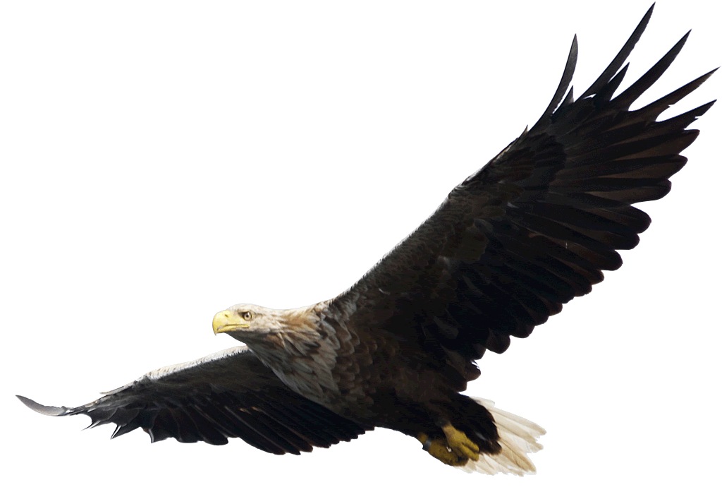

```python
# zebra.jpg ,  person.jpg , dog.jpg

from IPython.display import Image
Image(filename='MobileNet-Images/eagle.png', width=300,height=200)
```

```python
# zebra.jpg ,  person.jpg , dog.jpg
preprocessed_image = prepare_image('eagle.PNG')
predictions = mobile.predict(preprocessed_image)
results = imagenet_utils.decode_predictions(predictions)
results
```

```
[[('n01614925', 'bald_eagle', 0.87977165),
  ('n01616318', 'vulture', 0.11552734),
  ('n01608432', 'kite', 0.0042370204),
  ('n01795545', 'black_grouse', 0.00011052058),
  ('n02012849', 'crane', 7.262356e-05)]]
```

```python
from PIL import Image
```

```python
import numpy as np
import keras
from keras import backend as K
from keras.layers.core import Dense, Activation
from keras.optimizers import Adam
from keras.metrics import categorical_crossentropy
from keras.preprocessing.image import ImageDataGenerator
from keras.preprocessing import image
from keras.models import Model
from keras.applications import imagenet_utils
from sklearn.metrics import confusion_matrix
import itertools
import matplotlib.pyplot as plt
%matplotlib inline
```

```python
mobile = keras.applications.mobilenet.MobileNet()
```

```python
def prepare_image(file):
    img_path = 'MobileNet-Images/'
    img = image.load_img(img_path + file, target_size=(224, 224))
    img_array = image.img_to_array(img)
    img_array_expanded_dims = np.expand_dims(img_array, axis=0)
    return keras.applications.mobilenet.preprocess_input(img_array_expanded_dims)
```

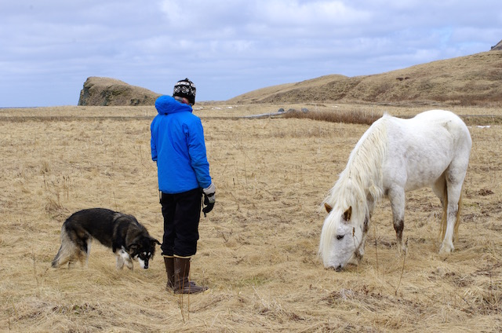

```python
from IPython.display import Image
Image(filename='MobileNet-Images/person.jpg', width=300,height=200)
```

```python
preprocessed_image = prepare_image('person.jpg')
predictions = mobile.predict(preprocessed_image)
results = imagenet_utils.decode_predictions(predictions)
results
```

```
[[('n02437616', 'llama', 0.8035083),
  ('n02105412', 'kelpie', 0.044872757),
  ('n02412080', 'ram', 0.02923027),
  ('n02092002', 'Scottish_deerhound', 0.014410912),
  ('n02395406', 'hog', 0.010786462)]]
```

```python
preprocessed_image = prepare_image('dog.jpg')
predictions = mobile.predict(preprocessed_image)
results = imagenet_utils.decode_predictions(predictions)
results
```

```
[[('n02110063', 'malamute', 0.4130244),
  ('n02088094', 'Afghan_hound', 0.05794209),
  ('n02106166', 'Border_collie', 0.04629636),
  ('n02102040', 'English_springer', 0.044394184),
  ('n02110185', 'Siberian_husky', 0.042014215)]]
```